# Risk Factor Analysis

## Outcome Variable

**Outcome Variable:** haz

## Predictor Variables

**Intervention Variable:** earlybf

**Adjustment Set:**

- arm
- sex
- W_mage
- meducyrs
- feducyrs
- hhwealth_quart
- hfoodsec
- W_mhtcm
- W_mwtkg
- W_mbmi
- vagbrth
- W_gagebrth
- W_birthwt
- W_birthlen
- W_nrooms
- W_nchldlt5
- brthmon
- W_parity
- impfloor
- impsan
- safeh20
- delta_W_mage
- delta_meducyrs
- delta_feducyrs
- delta_hhwealth_quart
- delta_hfoodsec
- delta_W_mhtcm
- delta_W_mwtkg
- delta_W_mbmi
- delta_vagbrth
- delta_W_gagebrth
- delta_W_birthwt
- delta_W_birthlen
- delta_W_nrooms
- delta_W_nchldlt5
- delta_brthmon
- delta_W_parity
- delta_impfloor
- delta_impsan
- delta_safeh20

## Stratifying Variables

The analysis was stratified on these variable(s):

- agecat
- studyid
- country

## Data Summary

| agecat | studyid | country | earlybf | n_cell | n | outcome_variable |
| --- | --- | --- | --- | --- | --- | --- |
| Birth | EE | PAKISTAN | 1 | 44 | 229 | haz |
| Birth | EE | PAKISTAN | 0 | 185 | 229 | haz |
| Birth | GMS-Nepal | NEPAL | 1 | 180 | 632 | haz |
| Birth | GMS-Nepal | NEPAL | 0 | 452 | 632 | haz |
| Birth | JiVitA-3 | BANGLADESH | 1 | 236 | 22370 | haz |
| Birth | JiVitA-3 | BANGLADESH | 0 | 22134 | 22370 | haz |
| Birth | JiVitA-4 | BANGLADESH | 1 | 1912 | 2823 | haz |
| Birth | JiVitA-4 | BANGLADESH | 0 | 911 | 2823 | haz |
| Birth | MAL-ED | BANGLADESH | 1 | 147 | 230 | haz |
| Birth | MAL-ED | BANGLADESH | 0 | 83 | 230 | haz |
| Birth | MAL-ED | BRAZIL | 1 | 28 | 65 | haz |
| Birth | MAL-ED | BRAZIL | 0 | 37 | 65 | haz |
| Birth | MAL-ED | INDIA | 1 | 32 | 46 | haz |
| Birth | MAL-ED | INDIA | 0 | 14 | 46 | haz |
| Birth | MAL-ED | NEPAL | 1 | 14 | 27 | haz |
| Birth | MAL-ED | NEPAL | 0 | 13 | 27 | haz |
| Birth | MAL-ED | PERU | 1 | 175 | 233 | haz |
| Birth | MAL-ED | PERU | 0 | 58 | 233 | haz |
| Birth | MAL-ED | SOUTH AFRICA | 1 | 69 | 111 | haz |
| Birth | MAL-ED | SOUTH AFRICA | 0 | 42 | 111 | haz |
| Birth | MAL-ED | TANZANIA, UNITED REPUBLIC OF | 1 | 111 | 125 | haz |
| Birth | MAL-ED | TANZANIA, UNITED REPUBLIC OF | 0 | 14 | 125 | haz |
| Birth | NIH-Crypto | BANGLADESH | 1 | 634 | 732 | haz |
| Birth | NIH-Crypto | BANGLADESH | 0 | 98 | 732 | haz |
| Birth | SAS-CompFeed | INDIA | 1 | 86 | 1207 | haz |
| Birth | SAS-CompFeed | INDIA | 0 | 1121 | 1207 | haz |
| Birth | ZVITAMBO | ZIMBABWE | 1 | 6556 | 12354 | haz |
| Birth | ZVITAMBO | ZIMBABWE | 0 | 5798 | 12354 | haz |
| 6 months | EE | PAKISTAN | 1 | 68 | 362 | haz |
| 6 months | EE | PAKISTAN | 0 | 294 | 362 | haz |

[output cut: 52 more lines]

The following strata were considered:

- agecat: 24 months, studyid: EE, country: PAKISTAN
- agecat: 24 months, studyid: GMS-Nepal, country: NEPAL
- agecat: 24 months, studyid: JiVitA-3, country: BANGLADESH
- agecat: 24 months, studyid: JiVitA-4, country: BANGLADESH
- agecat: 24 months, studyid: MAL-ED, country: BANGLADESH
- agecat: 24 months, studyid: MAL-ED, country: BRAZIL
- agecat: 24 months, studyid: MAL-ED, country: INDIA
- agecat: 24 months, studyid: MAL-ED, country: NEPAL
- agecat: 24 months, studyid: MAL-ED, country: PERU
- agecat: 24 months, studyid: MAL-ED, country: SOUTH AFRICA
- agecat: 24 months, studyid: MAL-ED, country: TANZANIA, UNITED REPUBLIC OF
- agecat: 24 months, studyid: NIH-Crypto, country: BANGLADESH
- agecat: 24 months, studyid: ZVITAMBO, country: ZIMBABWE
- agecat: 6 months, studyid: EE, country: PAKISTAN
- agecat: 6 months, studyid: GMS-Nepal, country: NEPAL
- agecat: 6 months, studyid: JiVitA-3, country: BANGLADESH
- agecat: 6 months, studyid: JiVitA-4, country: BANGLADESH
- agecat: 6 months, studyid: MAL-ED, country: BANGLADESH
- agecat: 6 months, studyid: MAL-ED, country: BRAZIL
- agecat: 6 months, studyid: MAL-ED, country: INDIA
- agecat: 6 months, studyid: MAL-ED, country: NEPAL
- agecat: 6 months, studyid: MAL-ED, country: PERU
- agecat: 6 months, studyid: MAL-ED, country: SOUTH AFRICA
- agecat: 6 months, studyid: MAL-ED, country: TANZANIA, UNITED REPUBLIC OF
- agecat: 6 months, studyid: NIH-Crypto, country: BANGLADESH
- agecat: 6 months, studyid: SAS-CompFeed, country: INDIA
- agecat: 6 months, studyid: ZVITAMBO, country: ZIMBABWE
- agecat: Birth, studyid: EE, country: PAKISTAN
- agecat: Birth, studyid: GMS-Nepal, country: NEPAL
- agecat: Birth, studyid: JiVitA-3, country: BANGLADESH
- agecat: Birth, studyid: JiVitA-4, country: BANGLADESH
- agecat: Birth, studyid: MAL-ED, country: BANGLADESH
- agecat: Birth, studyid: MAL-ED, country: BRAZIL
- agecat: Birth, studyid: MAL-ED, country: INDIA
- agecat: Birth, studyid: MAL-ED, country: NEPAL
- agecat: Birth, studyid: MAL-ED, country: PERU
- agecat: Birth, studyid: MAL-ED, country: SOUTH AFRICA
- agecat: Birth, studyid: MAL-ED, country: TANZANIA, UNITED REPUBLIC OF
- agecat: Birth, studyid: NIH-Crypto, country: BANGLADESH
- agecat: Birth, studyid: SAS-CompFeed, country: INDIA
- agecat: Birth, studyid: ZVITAMBO, country: ZIMBABWE

### Dropped Strata

Some strata were dropped due to rare outcomes:

- agecat: 24 months, studyid: JiVitA-3, country: BANGLADESH

## Methods Detail

We’re interested in the causal parameters $E[Y_a]$ for all values of $a \in \mathcal{A}$. These parameters represent the mean outcome if, possibly contrary to fact, we intervened to set all units to have $A=a$. Under the randomization and positivity assumptions, these are identified by the statistical parameters $\psi_a=E_W[E_{Y|A,W}(Y|A=a,W)]$. In addition, we’re interested in the mean of $Y$, $E[Y]$ under no intervention (the observed mean). We will estimate these parameters by using SuperLearner to fit the relevant likelihood factors – $E_{Y|A,W}(Y|A=a,W)$ and $p(A=a|W)$, and then updating our likelihood fit using a joint TMLE.

For unadjusted analyses ($W=\{\}$), initial likelihoods were estimated using Lrnr_glm to estimate the simple $E(Y|A)$ and Lrnr_mean to estimate $p(A)$. For adjusted analyses, a small library containing Lrnr_glmnet, Lrnr_xgboost, and Lrnr_mean was used.

Having estimated these parameters, we will then use the delta method to estimate relative risks and attributable risks relative to a prespecified baseline level of $A$.

# Results Detail

## Results Plots

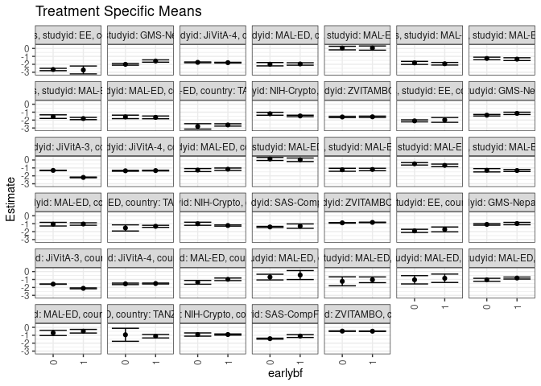

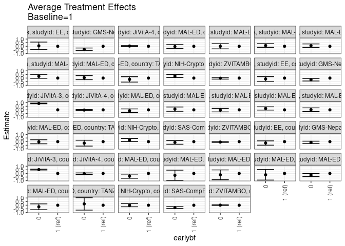

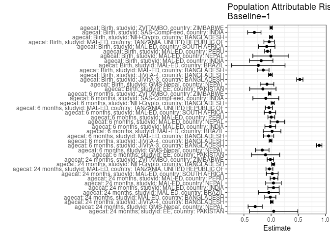

## Results Table

### Parameter: TSM

| agecat | studyid | country | intervention_level | baseline_level | estimate | ci_lower | ci_upper |
| --- | --- | --- | --- | --- | --- | --- | --- |
| Birth | EE | PAKISTAN | 1 | NA | -1.7198213 | -2.0251799 | -1.4144628 |
| Birth | EE | PAKISTAN | 0 | NA | -1.9075970 | -2.1088416 | -1.7063525 |
| Birth | GMS-Nepal | NEPAL | 1 | NA | -0.9823168 | -1.1320125 | -0.8326212 |
| Birth | GMS-Nepal | NEPAL | 0 | NA | -1.0876045 | -1.1851404 | -0.9900687 |
| Birth | JiVitA-3 | BANGLADESH | 1 | NA | -2.1173359 | -2.1757734 | -2.0588983 |
| Birth | JiVitA-3 | BANGLADESH | 0 | NA | -1.5872734 | -1.6068408 | -1.5677061 |
| Birth | JiVitA-4 | BANGLADESH | 1 | NA | -1.5101157 | -1.5673048 | -1.4529266 |
| Birth | JiVitA-4 | BANGLADESH | 0 | NA | -1.5477610 | -1.6413673 | -1.4541548 |
| Birth | MAL-ED | BANGLADESH | 1 | NA | -0.9768290 | -1.1361223 | -0.8175358 |
| Birth | MAL-ED | BANGLADESH | 0 | NA | -1.3572309 | -1.5961027 | -1.1183591 |
| Birth | MAL-ED | BRAZIL | 1 | NA | -0.4414866 | -1.0069720 | 0.1239989 |
| Birth | MAL-ED | BRAZIL | 0 | NA | -0.6974873 | -1.0570302 | -0.3379445 |
| Birth | MAL-ED | INDIA | 1 | NA | -1.0401600 | -1.4023807 | -0.6779393 |
| Birth | MAL-ED | INDIA | 0 | NA | -1.2332551 | -1.7982072 | -0.6683031 |
| Birth | MAL-ED | NEPAL | 1 | NA | -0.8482736 | -1.3764562 | -0.3200910 |
| Birth | MAL-ED | NEPAL | 0 | NA | -1.0383474 | -1.5606502 | -0.5160445 |
| Birth | MAL-ED | PERU | 1 | NA | -0.8176585 | -0.9457059 | -0.6896112 |
| Birth | MAL-ED | PERU | 0 | NA | -1.0474833 | -1.2413700 | -0.8535966 |
| Birth | MAL-ED | SOUTH AFRICA | 1 | NA | -0.4897847 | -0.7193416 | -0.2602279 |
| Birth | MAL-ED | SOUTH AFRICA | 0 | NA | -0.7051470 | -1.0330901 | -0.3772039 |
| Birth | MAL-ED | TANZANIA, UNITED REPUBLIC OF | 1 | NA | -1.1194721 | -1.3393777 | -0.8995665 |
| Birth | MAL-ED | TANZANIA, UNITED REPUBLIC OF | 0 | NA | -0.9382476 | -1.7602803 | -0.1162149 |
| Birth | NIH-Crypto | BANGLADESH | 1 | NA | -0.9081189 | -0.9832101 | -0.8330277 |
| Birth | NIH-Crypto | BANGLADESH | 0 | NA | -0.9091536 | -1.1122967 | -0.7060105 |
| Birth | SAS-CompFeed | INDIA | 1 | NA | -1.0994066 | -1.2772210 | -0.9215922 |
| Birth | SAS-CompFeed | INDIA | 0 | NA | -1.4308867 | -1.4933116 | -1.3684618 |
| Birth | ZVITAMBO | ZIMBABWE | 1 | NA | -0.4901386 | -0.5206380 | -0.4596393 |
| Birth | ZVITAMBO | ZIMBABWE | 0 | NA | -0.4779977 | -0.5094356 | -0.4465597 |
| 6 months | EE | PAKISTAN | 1 | NA | -1.9814470 | -2.2829533 | -1.6799406 |
| 6 months | EE | PAKISTAN | 0 | NA | -2.1023153 | -2.2300491 | -1.9745814 |
| 6 months | GMS-Nepal | NEPAL | 1 | NA | -1.1551078 | -1.3028612 | -1.0073544 |
| 6 months | GMS-Nepal | NEPAL | 0 | NA | -1.3831968 | -1.4802504 | -1.2861431 |
| 6 months | JiVitA-3 | BANGLADESH | 1 | NA | -2.1972146 | -2.2431010 | -2.1513282 |
| 6 months | JiVitA-3 | BANGLADESH | 0 | NA | -1.3111059 | -1.3347135 | -1.2874984 |
| 6 months | JiVitA-4 | BANGLADESH | 1 | NA | -1.3342446 | -1.3804615 | -1.2880278 |
| 6 months | JiVitA-4 | BANGLADESH | 0 | NA | -1.3595004 | -1.4179596 | -1.3010413 |
| 6 months | MAL-ED | BANGLADESH | 1 | NA | -1.1602522 | -1.3098867 | -1.0106178 |
| 6 months | MAL-ED | BANGLADESH | 0 | NA | -1.2712640 | -1.4629018 | -1.0796263 |
| 6 months | MAL-ED | BRAZIL | 1 | NA | 0.0296170 | -0.1921570 | 0.2513909 |
| 6 months | MAL-ED | BRAZIL | 0 | NA | 0.1328490 | -0.0590993 | 0.3247973 |
| 6 months | MAL-ED | INDIA | 1 | NA | -1.1967799 | -1.3502794 | -1.0432805 |
| 6 months | MAL-ED | INDIA | 0 | NA | -1.2352090 | -1.4239208 | -1.0464971 |
| 6 months | MAL-ED | NEPAL | 1 | NA | -0.6782230 | -0.8422201 | -0.5142258 |
| 6 months | MAL-ED | NEPAL | 0 | NA | -0.4817278 | -0.6354764 | -0.3279791 |
| 6 months | MAL-ED | PERU | 1 | NA | -1.3278215 | -1.4549242 | -1.2007189 |
| 6 months | MAL-ED | PERU | 0 | NA | -1.2950013 | -1.5053302 | -1.0846724 |
| 6 months | MAL-ED | SOUTH AFRICA | 1 | NA | -1.0391757 | -1.1935052 | -0.8848463 |
| 6 months | MAL-ED | SOUTH AFRICA | 0 | NA | -1.0603287 | -1.2898470 | -0.8308103 |
| 6 months | MAL-ED | TANZANIA, UNITED REPUBLIC OF | 1 | NA | -1.3282862 | -1.4574530 | -1.1991194 |
| 6 months | MAL-ED | TANZANIA, UNITED REPUBLIC OF | 0 | NA | -1.5351072 | -1.9215488 | -1.1486656 |
| 6 months | NIH-Crypto | BANGLADESH | 1 | NA | -1.2284772 | -1.3050091 | -1.1519453 |
| 6 months | NIH-Crypto | BANGLADESH | 0 | NA | -1.0064009 | -1.2030238 | -0.8097780 |
| 6 months | SAS-CompFeed | INDIA | 1 | NA | -1.3046030 | -1.5804232 | -1.0287828 |
| 6 months | SAS-CompFeed | INDIA | 0 | NA | -1.4110959 | -1.4864420 | -1.3357497 |
| 6 months | ZVITAMBO | ZIMBABWE | 1 | NA | -0.8358850 | -0.8710770 | -0.8006930 |
| 6 months | ZVITAMBO | ZIMBABWE | 0 | NA | -0.8914684 | -0.9296881 | -0.8532487 |
| 24 months | EE | PAKISTAN | 1 | NA | -2.7156113 | -3.2143334 | -2.2168893 |
| 24 months | EE | PAKISTAN | 0 | NA | -2.6545211 | -2.8030470 | -2.5059952 |
| 24 months | GMS-Nepal | NEPAL | 1 | NA | -1.5865468 | -1.7345155 | -1.4385782 |
| 24 months | GMS-Nepal | NEPAL | 0 | NA | -2.0025638 | -2.1117824 | -1.8933453 |
| 24 months | JiVitA-4 | BANGLADESH | 1 | NA | -1.7921262 | -1.8368970 | -1.7473554 |
| 24 months | JiVitA-4 | BANGLADESH | 0 | NA | -1.7557088 | -1.8097298 | -1.7016878 |
| 24 months | MAL-ED | BANGLADESH | 1 | NA | -1.9588366 | -2.1132522 | -1.8044210 |
| 24 months | MAL-ED | BANGLADESH | 0 | NA | -1.9873188 | -2.2006364 | -1.7740011 |
| 24 months | MAL-ED | BRAZIL | 1 | NA | 0.0483309 | -0.2143103 | 0.3109721 |
| 24 months | MAL-ED | BRAZIL | 0 | NA | 0.0479454 | -0.1783320 | 0.2742228 |
| 24 months | MAL-ED | INDIA | 1 | NA | -1.9304806 | -2.0959807 | -1.7649804 |
| 24 months | MAL-ED | INDIA | 0 | NA | -1.8239163 | -2.0148059 | -1.6330266 |
| 24 months | MAL-ED | NEPAL | 1 | NA | -1.3512191 | -1.5280971 | -1.1743412 |
| 24 months | MAL-ED | NEPAL | 0 | NA | -1.2650711 | -1.4266908 | -1.1034514 |
| 24 months | MAL-ED | PERU | 1 | NA | -1.8059953 | -1.9478002 | -1.6641904 |
| 24 months | MAL-ED | PERU | 0 | NA | -1.5655065 | -1.7924705 | -1.3385425 |
| 24 months | MAL-ED | SOUTH AFRICA | 1 | NA | -1.6580360 | -1.8323511 | -1.4837208 |
| 24 months | MAL-ED | SOUTH AFRICA | 0 | NA | -1.5995988 | -1.8198057 | -1.3793918 |
| 24 months | MAL-ED | TANZANIA, UNITED REPUBLIC OF | 1 | NA | -2.6144565 | -2.7597255 | -2.4691875 |
| 24 months | MAL-ED | TANZANIA, UNITED REPUBLIC OF | 0 | NA | -2.7988295 | -3.1378710 | -2.4597880 |
| 24 months | NIH-Crypto | BANGLADESH | 1 | NA | -1.4794220 | -1.5717435 | -1.3871004 |
| 24 months | NIH-Crypto | BANGLADESH | 0 | NA | -1.2039060 | -1.3874075 | -1.0204046 |
| 24 months | ZVITAMBO | ZIMBABWE | 1 | NA | -1.5873083 | -1.6730907 | -1.5015259 |
| 24 months | ZVITAMBO | ZIMBABWE | 0 | NA | -1.6080131 | -1.6935196 | -1.5225066 |

### Parameter: E(Y)

| agecat | studyid | country | intervention_level | baseline_level | estimate | ci_lower | ci_upper |
| --- | --- | --- | --- | --- | --- | --- | --- |
| Birth | EE | PAKISTAN | NA | NA | -1.8713537 | -2.0647180 | -1.6779894 |
| Birth | GMS-Nepal | NEPAL | NA | NA | -1.0578481 | -1.1411010 | -0.9745953 |
| Birth | JiVitA-3 | BANGLADESH | NA | NA | -1.5896710 | -1.6089649 | -1.5703770 |
| Birth | JiVitA-4 | BANGLADESH | NA | NA | -1.5232908 | -1.5723277 | -1.4742539 |
| Birth | MAL-ED | BANGLADESH | NA | NA | -1.1218261 | -1.2566576 | -0.9869945 |
| Birth | MAL-ED | BRAZIL | NA | NA | -0.6760000 | -0.9521457 | -0.3998543 |
| Birth | MAL-ED | INDIA | NA | NA | -1.2221739 | -1.5203945 | -0.9239534 |
| Birth | MAL-ED | NEPAL | NA | NA | -0.8533333 | -1.2104864 | -0.4961803 |
| Birth | MAL-ED | PERU | NA | NA | -0.8827897 | -1.0001058 | -0.7654736 |
| Birth | MAL-ED | SOUTH AFRICA | NA | NA | -0.5709009 | -0.7569265 | -0.3848753 |
| Birth | MAL-ED | TANZANIA, UNITED REPUBLIC OF | NA | NA | -1.1556000 | -1.3655361 | -0.9456639 |
| Birth | NIH-Crypto | BANGLADESH | NA | NA | -0.9094945 | -0.9809370 | -0.8380521 |
| Birth | SAS-CompFeed | INDIA | NA | NA | -1.4072245 | -1.4817853 | -1.3326638 |
| Birth | ZVITAMBO | ZIMBABWE | NA | NA | -0.4895257 | -0.5113672 | -0.4676841 |
| 6 months | EE | PAKISTAN | NA | NA | -2.0838858 | -2.2054394 | -1.9623322 |
| 6 months | GMS-Nepal | NEPAL | NA | NA | -1.3175310 | -1.3993963 | -1.2356656 |
| 6 months | JiVitA-3 | BANGLADESH | NA | NA | -1.3130932 | -1.3362359 | -1.2899505 |
| 6 months | JiVitA-4 | BANGLADESH | NA | NA | -1.3447940 | -1.3820261 | -1.3075620 |
| 6 months | MAL-ED | BANGLADESH | NA | NA | -1.2056389 | -1.3233420 | -1.0879358 |
| 6 months | MAL-ED | BRAZIL | NA | NA | 0.0475758 | -0.0963508 | 0.1915023 |
| 6 months | MAL-ED | INDIA | NA | NA | -1.2115254 | -1.3298727 | -1.0931782 |
| 6 months | MAL-ED | NEPAL | NA | NA | -0.5615819 | -0.6741832 | -0.4489807 |
| 6 months | MAL-ED | PERU | NA | NA | -1.3236661 | -1.4316775 | -1.2156546 |
| 6 months | MAL-ED | SOUTH AFRICA | NA | NA | -1.0598800 | -1.1885688 | -0.9311912 |
| 6 months | MAL-ED | TANZANIA, UNITED REPUBLIC OF | NA | NA | -1.3687449 | -1.4907629 | -1.2467270 |
| 6 months | NIH-Crypto | BANGLADESH | NA | NA | -1.1986783 | -1.2700937 | -1.1272630 |
| 6 months | SAS-CompFeed | INDIA | NA | NA | -1.4018563 | -1.4810585 | -1.3226541 |
| 6 months | ZVITAMBO | ZIMBABWE | NA | NA | -0.8625370 | -0.8897591 | -0.8353150 |
| 24 months | EE | PAKISTAN | NA | NA | -2.6678252 | -2.8138884 | -2.5217620 |
| 24 months | GMS-Nepal | NEPAL | NA | NA | -1.8793783 | -1.9705101 | -1.7882464 |
| 24 months | JiVitA-4 | BANGLADESH | NA | NA | -1.7807218 | -1.8162478 | -1.7451958 |
| 24 months | MAL-ED | BANGLADESH | NA | NA | -1.9735782 | -2.1004502 | -1.8467062 |
| 24 months | MAL-ED | BRAZIL | NA | NA | 0.0061144 | -0.1625850 | 0.1748138 |
| 24 months | MAL-ED | INDIA | NA | NA | -1.8861894 | -2.0110006 | -1.7613783 |
| 24 months | MAL-ED | NEPAL | NA | NA | -1.3075877 | -1.4270718 | -1.1881037 |
| 24 months | MAL-ED | PERU | NA | NA | -1.7524710 | -1.8736426 | -1.6312994 |
| 24 months | MAL-ED | SOUTH AFRICA | NA | NA | -1.6365071 | -1.7722110 | -1.5008032 |
| 24 months | MAL-ED | TANZANIA, UNITED REPUBLIC OF | NA | NA | -2.6455607 | -2.7807256 | -2.5103959 |
| 24 months | NIH-Crypto | BANGLADESH | NA | NA | -1.4412646 | -1.5249156 | -1.3576135 |
| 24 months | ZVITAMBO | ZIMBABWE | NA | NA | -1.6006366 | -1.6621572 | -1.5391159 |

### Parameter: ATE

| agecat | studyid | country | intervention_level | baseline_level | estimate | ci_lower | ci_upper |
| --- | --- | --- | --- | --- | --- | --- | --- |
| Birth | EE | PAKISTAN | 1 | 1 | 0.0000000 | 0.0000000 | 0.0000000 |
| Birth | EE | PAKISTAN | 0 | 1 | -0.1877757 | -0.4837811 | 0.1082298 |
| Birth | GMS-Nepal | NEPAL | 1 | 1 | 0.0000000 | 0.0000000 | 0.0000000 |
| Birth | GMS-Nepal | NEPAL | 0 | 1 | -0.1052877 | -0.2778003 | 0.0672249 |
| Birth | JiVitA-3 | BANGLADESH | 1 | 1 | 0.0000000 | 0.0000000 | 0.0000000 |
| Birth | JiVitA-3 | BANGLADESH | 0 | 1 | 0.5300624 | 0.4705034 | 0.5896215 |
| Birth | JiVitA-4 | BANGLADESH | 1 | 1 | 0.0000000 | 0.0000000 | 0.0000000 |
| Birth | JiVitA-4 | BANGLADESH | 0 | 1 | -0.0376454 | -0.1474770 | 0.0721863 |
| Birth | MAL-ED | BANGLADESH | 1 | 1 | 0.0000000 | 0.0000000 | 0.0000000 |
| Birth | MAL-ED | BANGLADESH | 0 | 1 | -0.3804018 | -0.6677362 | -0.0930675 |
| Birth | MAL-ED | BRAZIL | 1 | 1 | 0.0000000 | 0.0000000 | 0.0000000 |
| Birth | MAL-ED | BRAZIL | 0 | 1 | -0.2560007 | -0.9648123 | 0.4528108 |
| Birth | MAL-ED | INDIA | 1 | 1 | 0.0000000 | 0.0000000 | 0.0000000 |
| Birth | MAL-ED | INDIA | 0 | 1 | -0.1930951 | -0.8724817 | 0.4862915 |
| Birth | MAL-ED | NEPAL | 1 | 1 | 0.0000000 | 0.0000000 | 0.0000000 |
| Birth | MAL-ED | NEPAL | 0 | 1 | -0.1900738 | -0.9160169 | 0.5358693 |
| Birth | MAL-ED | PERU | 1 | 1 | 0.0000000 | 0.0000000 | 0.0000000 |
| Birth | MAL-ED | PERU | 0 | 1 | -0.2298248 | -0.4377213 | -0.0219283 |
| Birth | MAL-ED | SOUTH AFRICA | 1 | 1 | 0.0000000 | 0.0000000 | 0.0000000 |
| Birth | MAL-ED | SOUTH AFRICA | 0 | 1 | -0.2153623 | -0.6167593 | 0.1860347 |
| Birth | MAL-ED | TANZANIA, UNITED REPUBLIC OF | 1 | 1 | 0.0000000 | 0.0000000 | 0.0000000 |
| Birth | MAL-ED | TANZANIA, UNITED REPUBLIC OF | 0 | 1 | 0.1812245 | -0.6724031 | 1.0348521 |
| Birth | NIH-Crypto | BANGLADESH | 1 | 1 | 0.0000000 | 0.0000000 | 0.0000000 |
| Birth | NIH-Crypto | BANGLADESH | 0 | 1 | -0.0010347 | -0.2143385 | 0.2122692 |
| Birth | SAS-CompFeed | INDIA | 1 | 1 | 0.0000000 | 0.0000000 | 0.0000000 |
| Birth | SAS-CompFeed | INDIA | 0 | 1 | -0.3314801 | -0.4594813 | -0.2034788 |
| Birth | ZVITAMBO | ZIMBABWE | 1 | 1 | 0.0000000 | 0.0000000 | 0.0000000 |
| Birth | ZVITAMBO | ZIMBABWE | 0 | 1 | 0.0121410 | -0.0302620 | 0.0545440 |
| 6 months | EE | PAKISTAN | 1 | 1 | 0.0000000 | 0.0000000 | 0.0000000 |
| 6 months | EE | PAKISTAN | 0 | 1 | -0.1208683 | -0.4397384 | 0.1980017 |
| 6 months | GMS-Nepal | NEPAL | 1 | 1 | 0.0000000 | 0.0000000 | 0.0000000 |
| 6 months | GMS-Nepal | NEPAL | 0 | 1 | -0.2280890 | -0.4036126 | -0.0525653 |
| 6 months | JiVitA-3 | BANGLADESH | 1 | 1 | 0.0000000 | 0.0000000 | 0.0000000 |
| 6 months | JiVitA-3 | BANGLADESH | 0 | 1 | 0.8861087 | 0.8353037 | 0.9369137 |
| 6 months | JiVitA-4 | BANGLADESH | 1 | 1 | 0.0000000 | 0.0000000 | 0.0000000 |
| 6 months | JiVitA-4 | BANGLADESH | 0 | 1 | -0.0252558 | -0.0975723 | 0.0470608 |
| 6 months | MAL-ED | BANGLADESH | 1 | 1 | 0.0000000 | 0.0000000 | 0.0000000 |
| 6 months | MAL-ED | BANGLADESH | 0 | 1 | -0.1110118 | -0.3555560 | 0.1335324 |
| 6 months | MAL-ED | BRAZIL | 1 | 1 | 0.0000000 | 0.0000000 | 0.0000000 |
| 6 months | MAL-ED | BRAZIL | 0 | 1 | 0.1032320 | -0.1918228 | 0.3982869 |
| 6 months | MAL-ED | INDIA | 1 | 1 | 0.0000000 | 0.0000000 | 0.0000000 |
| 6 months | MAL-ED | INDIA | 0 | 1 | -0.0384291 | -0.2820246 | 0.2051665 |
| 6 months | MAL-ED | NEPAL | 1 | 1 | 0.0000000 | 0.0000000 | 0.0000000 |
| 6 months | MAL-ED | NEPAL | 0 | 1 | 0.1964952 | -0.0291021 | 0.4220926 |
| 6 months | MAL-ED | PERU | 1 | 1 | 0.0000000 | 0.0000000 | 0.0000000 |
| 6 months | MAL-ED | PERU | 0 | 1 | 0.0328203 | -0.2136438 | 0.2792843 |
| 6 months | MAL-ED | SOUTH AFRICA | 1 | 1 | 0.0000000 | 0.0000000 | 0.0000000 |
| 6 months | MAL-ED | SOUTH AFRICA | 0 | 1 | -0.0211529 | -0.2984957 | 0.2561898 |
| 6 months | MAL-ED | TANZANIA, UNITED REPUBLIC OF | 1 | 1 | 0.0000000 | 0.0000000 | 0.0000000 |
| 6 months | MAL-ED | TANZANIA, UNITED REPUBLIC OF | 0 | 1 | -0.2068210 | -0.6124489 | 0.1988069 |
| 6 months | NIH-Crypto | BANGLADESH | 1 | 1 | 0.0000000 | 0.0000000 | 0.0000000 |
| 6 months | NIH-Crypto | BANGLADESH | 0 | 1 | 0.2220763 | 0.0110101 | 0.4331425 |
| 6 months | SAS-CompFeed | INDIA | 1 | 1 | 0.0000000 | 0.0000000 | 0.0000000 |
| 6 months | SAS-CompFeed | INDIA | 0 | 1 | -0.1064929 | -0.3580352 | 0.1450495 |
| 6 months | ZVITAMBO | ZIMBABWE | 1 | 1 | 0.0000000 | 0.0000000 | 0.0000000 |
| 6 months | ZVITAMBO | ZIMBABWE | 0 | 1 | -0.0555834 | -0.1045926 | -0.0065741 |
| 24 months | EE | PAKISTAN | 1 | 1 | 0.0000000 | 0.0000000 | 0.0000000 |
| 24 months | EE | PAKISTAN | 0 | 1 | 0.0610902 | -0.4597635 | 0.5819440 |
| 24 months | GMS-Nepal | NEPAL | 1 | 1 | 0.0000000 | 0.0000000 | 0.0000000 |
| 24 months | GMS-Nepal | NEPAL | 0 | 1 | -0.4160170 | -0.5981991 | -0.2338349 |
| 24 months | JiVitA-4 | BANGLADESH | 1 | 1 | 0.0000000 | 0.0000000 | 0.0000000 |
| 24 months | JiVitA-4 | BANGLADESH | 0 | 1 | 0.0364174 | -0.0298169 | 0.1026516 |
| 24 months | MAL-ED | BANGLADESH | 1 | 1 | 0.0000000 | 0.0000000 | 0.0000000 |
| 24 months | MAL-ED | BANGLADESH | 0 | 1 | -0.0284822 | -0.2882424 | 0.2312781 |
| 24 months | MAL-ED | BRAZIL | 1 | 1 | 0.0000000 | 0.0000000 | 0.0000000 |
| 24 months | MAL-ED | BRAZIL | 0 | 1 | -0.0003855 | -0.3556929 | 0.3549218 |
| 24 months | MAL-ED | INDIA | 1 | 1 | 0.0000000 | 0.0000000 | 0.0000000 |
| 24 months | MAL-ED | INDIA | 0 | 1 | 0.1065643 | -0.1466391 | 0.3597677 |
| 24 months | MAL-ED | NEPAL | 1 | 1 | 0.0000000 | 0.0000000 | 0.0000000 |
| 24 months | MAL-ED | NEPAL | 0 | 1 | 0.0861481 | -0.1546492 | 0.3269454 |
| 24 months | MAL-ED | PERU | 1 | 1 | 0.0000000 | 0.0000000 | 0.0000000 |
| 24 months | MAL-ED | PERU | 0 | 1 | 0.2404888 | -0.0277998 | 0.5087773 |
| 24 months | MAL-ED | SOUTH AFRICA | 1 | 1 | 0.0000000 | 0.0000000 | 0.0000000 |
| 24 months | MAL-ED | SOUTH AFRICA | 0 | 1 | 0.0584372 | -0.2228366 | 0.3397110 |
| 24 months | MAL-ED | TANZANIA, UNITED REPUBLIC OF | 1 | 1 | 0.0000000 | 0.0000000 | 0.0000000 |
| 24 months | MAL-ED | TANZANIA, UNITED REPUBLIC OF | 0 | 1 | -0.1843730 | -0.5533018 | 0.1845558 |
| 24 months | NIH-Crypto | BANGLADESH | 1 | 1 | 0.0000000 | 0.0000000 | 0.0000000 |
| 24 months | NIH-Crypto | BANGLADESH | 0 | 1 | 0.2755160 | 0.0701238 | 0.4809082 |
| 24 months | ZVITAMBO | ZIMBABWE | 1 | 1 | 0.0000000 | 0.0000000 | 0.0000000 |
| 24 months | ZVITAMBO | ZIMBABWE | 0 | 1 | -0.0207048 | -0.1403149 | 0.0989053 |

### Parameter: PAR

| agecat | studyid | country | intervention_level | baseline_level | estimate | ci_lower | ci_upper |
| --- | --- | --- | --- | --- | --- | --- | --- |
| Birth | EE | PAKISTAN | 1 | NA | -0.1515324 | -0.3935617 | 0.0904970 |
| Birth | GMS-Nepal | NEPAL | 1 | NA | -0.0755313 | -0.2009403 | 0.0498778 |
| Birth | JiVitA-3 | BANGLADESH | 1 | NA | 0.5276649 | 0.4698010 | 0.5855287 |
| Birth | JiVitA-4 | BANGLADESH | 1 | NA | -0.0131751 | -0.0482680 | 0.0219178 |
| Birth | MAL-ED | BANGLADESH | 1 | NA | -0.1449970 | -0.2515293 | -0.0384647 |
| Birth | MAL-ED | BRAZIL | 1 | NA | -0.2345134 | -0.7252237 | 0.2561968 |
| Birth | MAL-ED | INDIA | 1 | NA | -0.1820139 | -0.3973045 | 0.0332767 |
| Birth | MAL-ED | NEPAL | 1 | NA | -0.0050598 | -0.3360246 | 0.3259051 |
| Birth | MAL-ED | PERU | 1 | NA | -0.0651312 | -0.1183301 | -0.0119323 |
| Birth | MAL-ED | SOUTH AFRICA | 1 | NA | -0.0811162 | -0.2327168 | 0.0704844 |
| Birth | MAL-ED | TANZANIA, UNITED REPUBLIC OF | 1 | NA | -0.0361279 | -0.1322971 | 0.0600413 |
| Birth | NIH-Crypto | BANGLADESH | 1 | NA | -0.0013756 | -0.0295426 | 0.0267914 |
| Birth | SAS-CompFeed | INDIA | 1 | NA | -0.3078179 | -0.4303157 | -0.1853201 |
| Birth | ZVITAMBO | ZIMBABWE | 1 | NA | 0.0006130 | -0.0213181 | 0.0225441 |
| 6 months | EE | PAKISTAN | 1 | NA | -0.1024389 | -0.3626117 | 0.1577340 |
| 6 months | GMS-Nepal | NEPAL | 1 | NA | -0.1624232 | -0.2865782 | -0.0382681 |
| 6 months | JiVitA-3 | BANGLADESH | 1 | NA | 0.8841214 | 0.8345277 | 0.9337151 |
| 6 months | JiVitA-4 | BANGLADESH | 1 | NA | -0.0105494 | -0.0368889 | 0.0157901 |
| 6 months | MAL-ED | BANGLADESH | 1 | NA | -0.0453867 | -0.1393847 | 0.0486113 |
| 6 months | MAL-ED | BRAZIL | 1 | NA | 0.0179588 | -0.1442461 | 0.1801637 |
| 6 months | MAL-ED | INDIA | 1 | NA | -0.0147455 | -0.1136953 | 0.0842042 |
| 6 months | MAL-ED | NEPAL | 1 | NA | 0.1166410 | -0.0167920 | 0.2500741 |
| 6 months | MAL-ED | PERU | 1 | NA | 0.0041555 | -0.0586451 | 0.0669561 |
| 6 months | MAL-ED | SOUTH AFRICA | 1 | NA | -0.0207043 | -0.1257484 | 0.0843398 |
| 6 months | MAL-ED | TANZANIA, UNITED REPUBLIC OF | 1 | NA | -0.0404588 | -0.1054820 | 0.0245645 |
| 6 months | NIH-Crypto | BANGLADESH | 1 | NA | 0.0297989 | 0.0010763 | 0.0585214 |
| 6 months | SAS-CompFeed | INDIA | 1 | NA | -0.0972533 | -0.3350924 | 0.1405858 |
| 6 months | ZVITAMBO | ZIMBABWE | 1 | NA | -0.0266520 | -0.0495363 | -0.0037677 |
| 24 months | EE | PAKISTAN | 1 | NA | 0.0477861 | -0.3955656 | 0.4911379 |
| 24 months | GMS-Nepal | NEPAL | 1 | NA | -0.2928314 | -0.4228938 | -0.1627691 |
| 24 months | JiVitA-4 | BANGLADESH | 1 | NA | 0.0114044 | -0.0124906 | 0.0352993 |
| 24 months | MAL-ED | BANGLADESH | 1 | NA | -0.0147416 | -0.1166089 | 0.0871257 |
| 24 months | MAL-ED | BRAZIL | 1 | NA | -0.0422165 | -0.2333897 | 0.1489567 |
| 24 months | MAL-ED | INDIA | 1 | NA | 0.0442911 | -0.0593835 | 0.1479658 |
| 24 months | MAL-ED | NEPAL | 1 | NA | 0.0436314 | -0.0995262 | 0.1867890 |
| 24 months | MAL-ED | PERU | 1 | NA | 0.0535243 | -0.0173981 | 0.1244467 |
| 24 months | MAL-ED | SOUTH AFRICA | 1 | NA | 0.0215289 | -0.0864373 | 0.1294950 |
| 24 months | MAL-ED | TANZANIA, UNITED REPUBLIC OF | 1 | NA | -0.0311043 | -0.0944520 | 0.0322434 |
| 24 months | NIH-Crypto | BANGLADESH | 1 | NA | 0.0381574 | 0.0095769 | 0.0667379 |
| 24 months | ZVITAMBO | ZIMBABWE | 1 | NA | -0.0133282 | -0.0721708 | 0.0455143 |